# How

should we represent a given image, in order to minimzed its compressed size on our machines, maximize its uncompressed quality to our eyes, and minimize the time and complexity required to manage compression?

This is a question that every generation of humans, going forward, should attack. With all the resources of their times, to suit their times.

Created: 2020-08-22.

```python
import cv2 as cv
from scipy import fft
import sys
import numpy as np
import matplotlib.image as mpimg
import matplotlib.pyplot as plt

# Some weirdness. I should not have to do this.
sys.path.append('/usr/local/lib/python3.7/site-packages')
```

```python
img_path = '/Users/stefan/Desktop/red_pepper.jpeg'
```

### Load and visualize RGB values that describe the image

- The RGB representation of images exists because monitors have Red, Green, and Blue emittors.
- Monitors have Red, Green, and Blue emittors because these are the primary colors of light.

```python
# Read the RGB values of the image into an np.ndarray.
# We opt for the Matplotlib function because we will use their function to visualize the image.

# There is some discrepancy between the actual RGB values in these two representations.
img_bgr_alt = cv.imread(img_path, cv.IMREAD_COLOR)
img_rgb = mpimg.imread(img_path)

# But, for debugging, let's keep the OpenCV version as an alternate.
img_rgb_alt = img_bgr_alt.copy()
img_rgb_alt[:, :, 0] = img_bgr_alt[:, :, 2]
img_rgb_alt[:, :, 2] = img_bgr_alt[:, :, 0]

# And, we can maybe use OpenCV functions on the Matplotlib image; let's make a BGR version of it.
img_bgr = img_bgr_alt.copy()
img_bgr[:, :, 0] = img_bgr_alt[:, :, 2]
img_bgr[:, :, 2] = img_bgr_alt[:, :, 0]
```

```python
# Sanity check size.

img_rgb_shape = img_rgb.shape
img_bgr_shape = img_bgr.shape

assert img_rgb_shape == img_bgr_shape, (
    f'img_rgb_shape = {img_rgb_shape} != {img_bgr_shape} = img_idk_shape'
)
```

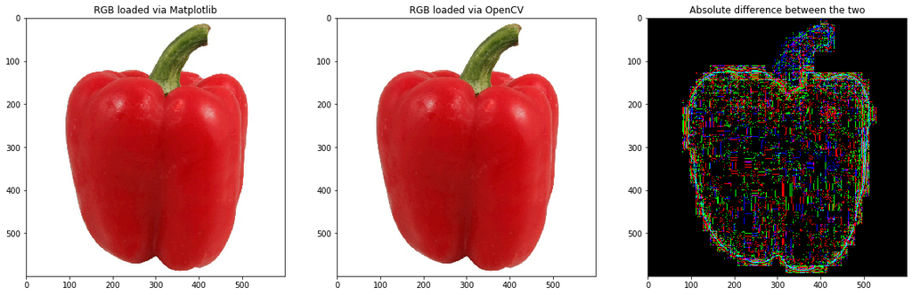

```python
# Visualize differences between the two methods of loading RGB values.

abs_p = np.vectorize(lambda n: abs(n))

fig, axs = plt.subplots(nrows=1, ncols=3,
                        figsize=(20, 60))

axs[0].set_title('RGB loaded via Matplotlib')
axs[0].imshow(X=img_rgb)

axs[1].set_title('RGB loaded via OpenCV')
axs[1].imshow(X=img_rgb_alt)

axs[2].set_title('Absolute difference between the two')
axs[2].imshow(X=(abs_p(img_rgb - img_rgb_alt)))

plt.show()
```

### Convert to YUV values that describe the same image

- The YUV representation of an image has one channel for brightness (Y) and two channels for color (UV).
- It exists because the human eye is sensitive enough to brightness that it makes sense to have an entire channel for brightness, and two for color (instead of having three channels for color, with brightnes implicitly encoded, like in the RGB representation).
- By "makes sense", I mean that if the same image were encoded and then decoded using the YUV and RGB representations, with the same encoded image size, the YUV-decoded image would look more similar to the original to the human eye than the RGB-decoded image.

```python
img_yuv = cv.cvtColor(img_bgr, cv.COLOR_BGR2YUV)
```

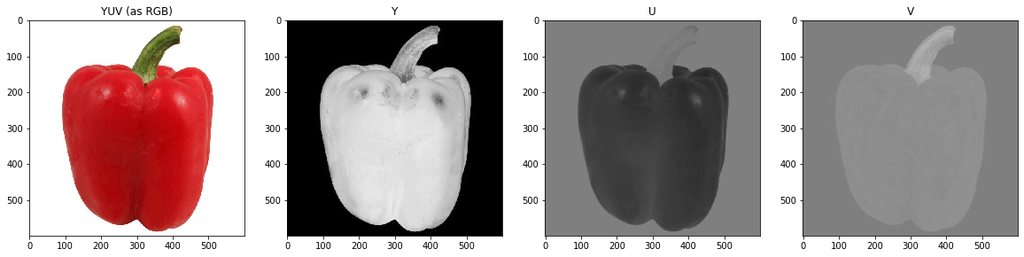

```python
# Visualize different channels of the YUV representation.

def invert_intensity(f):
    """Exists to make high numbers seem light, and low numbers seem dark."""
    return 255 - f

invert_intensity_p = np.vectorize(invert_intensity)


fig, axs = plt.subplots(nrows=1, ncols=4,
                        figsize=(20, 80))


axs[0].set_title('YUV (as RGB)')
axs[0].imshow(X=img_rgb)


y_val = img_yuv[:, :, 0]
y_val_inverted = invert_intensity_p(np.expand_dims(y_val, 2))
y_img = np.tile(y_val_inverted, [1, 1, 3])

axs[1].set_title('Y')
axs[1].imshow(X=y_img)


u_val = invert_intensity_p(img_yuv[:, :, 1:2])
u_val_inverted = invert_intensity_p(np.expand_dims(u_val, 2))
u_img = np.tile(u_val, [1, 1, 3])

axs[2].set_title('U')
axs[2].imshow(X=u_img)


v_val = invert_intensity_p(img_yuv[:, :, 2:3])
v_val_inverted = invert_intensity_p(np.expand_dims(v_val, 2))
v_img = np.tile(v_val, [1, 1, 3])

axs[3].set_title('V')
axs[3].imshow(X=v_img)


plt.show()
```

```python
img_rgb_double_converted = cv.cvtColor(img_yuv, cv.COLOR_YUV2BGR)
```

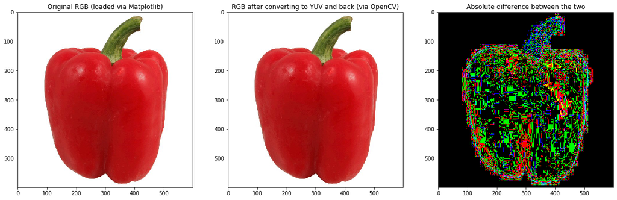

```python
# Visualize discrepancies that arise between an image is converted from RGB to YUV and back to RGB.

fig, axs = plt.subplots(nrows=1, ncols=3,
                        figsize=(20, 60))

axs[0].set_title('Original RGB (loaded via Matplotlib)')
axs[0].imshow(X=img_rgb)

axs[1].set_title('RGB after converting to YUV and back (via OpenCV)')
axs[1].imshow(X=img_rgb_double_converted)

axs[2].set_title('Absolute difference between the two')
axs[2].imshow(X=(abs_p(img_rgb - img_rgb_double_converted)))

plt.show()
```

- It seems that the RGB to YUV to RGB conversion loses some of the greenness of the pepper.
- It is probably no coincidence that Red and Green are opposites on the color wheel.
- Somehow, YUV seems to have doubled-down on the redness of the pepper.

### Compress the YUV representation of an image using the Discrete Cosine Transform

- This is what JPEG and many other image formats do.

```python
def compress_and_decompress_using_dct(a):
    """Change the basis of a matrix using the Fourier Transform, then change the basis back."""

    a_changed_basis = fft.dct(a)

    a_double_changed_basis = fft.idct(a_changed_basis)
    a_double_changed_basis = np.vectorize(int)(a_double_changed_basis)

    return a_changed_basis, a_double_changed_basis


y_val_changed_basis, y_val_double_changed_basis = compress_and_decompress_using_dct(y_val)
```

```python
# Sanity check sizes.

y_val_shape = y_val.shape
y_val_double_changed_basis_shape = y_val_double_changed_basis.shape

assert y_val_shape == y_val_double_changed_basis_shape, (
    f'y_val_shape = {y_val_shape} != {y_val_double_changed_basis_shape} = y_val_double_changed_basis_shape'
)
```

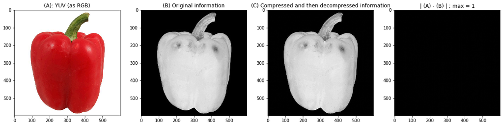

```python
# Visualize the effect of changing the basis of a matrix using the Fourier transforma and then changing it back.

def show_effect_of_compression_and_decompression(
    ref, original, double_changed_basis):

    fig, axs = plt.subplots(nrows=1, ncols=4,
                            figsize=(20, 80))


    axs[0].set_title('(A): YUV (as RGB)')
    axs[0].imshow(X=ref)


    original_inverted = invert_intensity_p(np.expand_dims(original, 2))
    original_img = np.tile(original_inverted, [1, 1, 3])

    axs[1].set_title('(B) Original information')
    axs[1].imshow(X=original_img)


    double_changed_basis_inverted = invert_intensity_p(np.expand_dims(double_changed_basis, 2))
    double_changed_basis_inverted_img = np.tile(double_changed_basis_inverted, [1, 1, 3])

    axs[2].set_title('(C) Compressed and then decompressed information')
    axs[2].imshow(X=double_changed_basis_inverted_img)


    diff_after_double_changed_basis = np.abs(original_img - double_changed_basis_inverted_img)

    title_str = f'| (A) - (B) | ; max = {np.max(diff_after_double_changed_basis)}'
    axs[3].set_title(title_str)

    axs[3].imshow(X=diff_after_double_changed_basis)


    plt.show()

show_effect_of_compression_and_decompression(img_rgb, y_val, y_val_double_changed_basis)
```

```
Clipping input data to the valid range for imshow with RGB data ([0..1] for floats or [0..255] for integers).
```

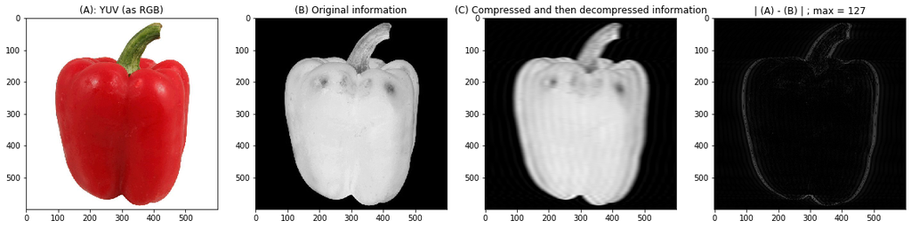

```python
def ordered_lossy_compress_and_decompress_using_dct(a, p):
    """Change the basis of a matrix using the Fourier Transform. Only keep the lowest frequency p proportion of the
    elements. Then change the basis back."""

    assert len(a.shape) == 2, f'a.shape = {a.shape} != 2'
    n_1, n_2 = a.shape

    a_flat = a.flatten()
    n = a_flat.shape[0]

    a_flat_changed_basis = fft.dct(a_flat, n=n)

    n_dim_kept = int(p * len(a_flat))
    a_flat_changed_basis_truncated = a_flat_changed_basis[0:n_dim_kept]

    a_flat_double_changed_basis = fft.idct(a_flat_changed_basis_truncated, n=n)
    a_flat_double_changed_basis = np.vectorize(int)(a_flat_double_changed_basis)

    a_changed_basis = np.reshape(a_flat_changed_basis, (n_1, n_2))
    a_double_changed_basis = np.reshape(a_flat_double_changed_basis, (n_1, n_2))

    return a_changed_basis, a_double_changed_basis


y_val_lossy_changed_basis, y_val_double_lossy_changed_basis = (
    ordered_lossy_compress_and_decompress_using_dct(y_val, p=0.07)
)

show_effect_of_compression_and_decompression(img_rgb, y_val, y_val_double_lossy_changed_basis)
```

- Note that the edges are most effected by the compression.
- This makes sense, because we are throwing away the highest frequency information first.

```python
# Try a different scheme for keeping p proportion of the elements.

# def erase_proportion_uniformly(a, p):
```

```python
# Visualize the entire YUV image when it is compressed and then decompressed.
# A table with {original, compressed and decompressed, diff} x {YUV, Y, U, V} cells.
```

#### Compress the YUV representation of an image using a mapping to a different basis space

- Different from the basis space of the Discrete Cosine Transform.
- The Discrete Cosine Transform benefits from the fact that its basis space is standard. No information about the basis vectors needs to be stored with the compressed file; that information lives in the protocol.
- If we are to have a different basis space, we must store information that defines it somehow. There are two options:
  - Store perturbations of the basis space of the Discrete Cosine Transform basis space.
  - Store entirely new basis vectors.
- In either case, it does not make sense to do this for a single image. It could only make sense if there are many images, so the extra overhead per image is small.
- My task now is to collect a set of images that have some basic consistency among them (maybe many images of Red Bell Peppers), and then to see if I can get a lower total memory footprint (sum of all compressed sizes, and extra overhead) than the default approach, for different desired quality settings.
- But, btw, it is not necessarily the case that there are no gains to be had on a single image. Consider:
  - The status quo approach is about storing coordinates in the Discrete Cosine Transform space.
  - The alternative approach is about storing coordinates in and the basis vectors of a space.
  - Perhaps, the same quality can be achieved at lower memory footprint in the second case. Perhaps!
- Also, note that as the number of images goes to infinity, the overhead of storing the basis space goes to zero. So, I could assume I can use whatever basis space I want, and then see if I can beat the DCT just on number of coordinates needed to produce a certain quality.